# forestControl

Tom Wilson

## Installation

To install using `devtools`;

```r
devtools::install_github("wilsontom/forestControl")
```

or from source;

```bash
git clone https://github.com/wilsontom/forestControl
R CMD build forestControl
R CMD INSTALL forestControl_0.1.0.tar.gz
```

## Usage

All the necessary parameters that are required for calculating selection frequency false positive rates can be extracted using the `extract_params` function. `extract_params` does not need to be explicitly executed; as it is already done so internally during the use of the selection frequency calculation functions. The folllowing is simply an exmaple showing the extracted parameters.

The output of `extract_params` is a list of four elements.

- **`Fn`** is the total number of features which are considered at each internal node. This parameter is commonly refered to as `mrty` in the random forest package.
- **`Ft`** is the total number of features present in the data set
- **`K`** is the average number of binary tests (internal nodes) across the entire forest.
- **`Tr`** is the total number of trees in the forest

`extract_params` is compatible with both `randomForest` and `ranger` objects.

```r
library(forestControl)
# For randomForest models

randomForest_model <- randomForest::randomForest(
                                        iris[,-5],factor(iris$Species),
                                          ntree = 100, keep.forest = TRUE)


randomForest_parmas <- extract_params(randomForest_model)

randomForest_parmas
```

```
## $Fn
## [1] 2
##
## $Ft
## [1] 4
##
## $K
## [1] 8
##
## $Tr
## [1] 100
```

```r
# For ranger models

ranger_model <- ranger::ranger(factor(iris$Species) ~., iris[,-5],
                                  write.forest = TRUE, num.trees = 100)

ranger_params <- extract_params(ranger_model)

ranger_params
```

```
## $Fn
## [1] 2
##
## $Ft
## [1] 4
##
## $K
## [1] 8
##
## $Tr
## [1] 100
```

## Selection Frequency Threshold

Using the extracted parameters (above) the selection frequency threshold (**sft**) for a specified false positive rate (FPR) can be calculated using a specified false positive rate (**alpha**).

```r
selec_freq_threshold <- sft(randomForest_model, alpha = 0.01)

selec_freq_threshold
```

```
## $sft
## [1] 230
##
## $prob
## [1] 0.008691391
```

A `sft` of 230 for an `alpha` of 0.01 means that for a feature to have a 99 % chance of true selection then it must have a selection frequency greater than or equal to 230 across the forest.

The `plot_sft` function shows the selection frequency thresholds for a sequence of false positive rates.

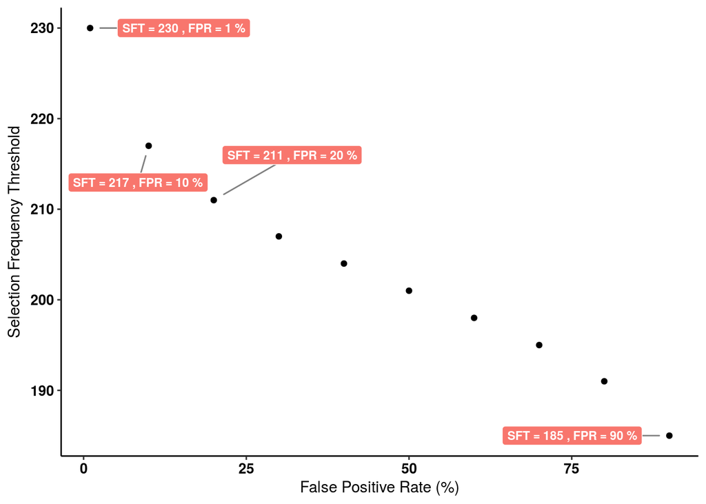

```r
plot_sft(randomForest_model)
```

## False Positive Rate Feature Selection

The `fpr_fs` funciton uses feature selection frequencies to determine te false positive rate of each feature. Instead of using a pre-defined **alpha** value for the whole model; the false positive rate is determined simultaneously for each individual feature using the feature selection frequency and model parameters (Fn, Ft, K and Tr)

```r
fpr_fs_res <- fpr_fs(randomForest_model)

tibble::as.tibble(fpr_fs_res) %>% dplyr::arrange(-freq)
```

```
## # A tibble: 4 x 2
##    freq       fpr
##   <dbl>     <dbl>
## 1   260 0.0000011
## 2   259 0.0000017
## 3   159 0.9997387
## 4   107 1.0000000
```